# Supervised Learning in Data Mining

Hridhay Mehta

# Regression and Classification

## Boston Housing Data

### Executive Summary

The Boston Housing dataset consisting of 506 observations with 14 variables. The response variable is **medv**, the median housing price which is continuous in nature. Using a 70-30 sample split we fit multiple models on the training data and compare the In-sample and Out-sample Average Sum Square Errors (ASE). The table below summarizes the methods:

| Sr. | Type | ASE | Out-Sample |
| --- | --- | --- | --- |
| 1 | Linear Regression | 23.597306 | 18.688102 |
| 2 | Regression Tree | 16.385094 | 23.013215 |
| 3 | Bagging | 12.959958 | 10.727727 |
| 4 | Random Forest | 12.74322 | 7.157639 |
| 5 | Boosting | 2.10690 | 6.924797 |
| 6 | GAM | 8.432493 | 16.161948 |
| 7 | Neural Network | 6.859694 | 11.741971 |

For the Linear Regression model we fit using AIC and BIC criterion and try LASSO variable selection. The best MSE and $R^2_{adj}$ is found in the AIC model.  
A Regression tree is fit since the response is continuous. An optimal tree with 6 terminal nodes was built.  
Advanced trees such as Bagging, Random Forest and Boosting are also fit and optimized.  
Boosting shows the best performance in-sample and out-of-sample.  
A General Additive Model is fit with **chas** and **rad** as linear terms and splines for all other terms and **age**, **black** and **zn** were not significant so were removed.  
A Neural network with 2 hidden layers each having 3 nodes was found to show least variation on error between train and test set.

### Exploratory Data Analysis

Split the data as 70% training and 30% testing. For all model training we will stick only to training set.

```r
set.seed(13474723)
data(Boston)
index <- sample(nrow(Boston), nrow(Boston)*0.7)
boston.train <- Boston[index,]
boston.test <- Boston[-index,]
```

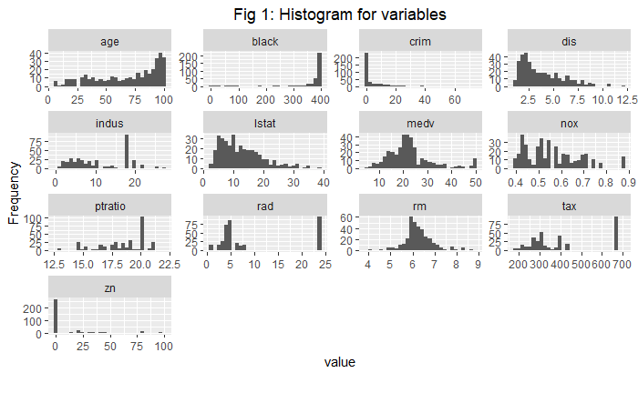

```r
plot_histogram(boston.train, title="Fig 1: Histogram for variables", theme_config = list(plot.title = element_text(hjust = 0.5)))
```

```r
str(boston.train)
```

```
'data.frame':   354 obs. of  14 variables:
 $ crim   : num  8.983 4.3488 0.0907 6.3931 0.1966 ...
 $ zn     : num  0 0 45 0 22 21 0 0 0 0 ...
 $ indus  : num  18.1 18.1 3.44 18.1 5.86 ...
 $ chas   : int  1 0 0 0 0 0 0 1 0 0 ...
 $ nox    : num  0.77 0.58 0.437 0.584 0.431 0.439 0.624 0.77 0.51 0.713 ...
 $ rm     : num  6.21 6.17 6.95 6.16 6.23 ...
 $ age    : num  97.4 84 21.5 97.4 79.2 45.7 98.9 83.4 88.5 84.4 ...
 $ dis    : num  2.12 3.03 6.48 2.21 8.06 ...
 $ rad    : int  24 24 5 24 7 4 4 24 5 24 ...
 $ tax    : num  666 666 398 666 330 243 437 666 296 666 ...
 $ ptratio: num  20.2 20.2 15.2 20.2 19.1 16.8 21.2 20.2 16.6 20.2 ...
 $ black  : num  378 397 378 303 376 ...
 $ lstat  : num  17.6 16.3 5.1 24.1 10.2 ...
 $ medv   : num  17.8 19.9 37 13.3 20.5 19.7 19.2 22.7 23.1 20 ...
```

```r
table <- data.frame(matrix(ncol = 2, nrow = 7))
names(table) <- c("Type","ASE")
```

### Linear Regression

Stepwise with AIC and BIC as criterion and LASSO regression models are fit.  
The lowest MSE and best $R^2_{adj}$ is seen with stepwise AIC regression.

$$medv = 36.51 - 0.57*lstat + 3.72*rm - 0.87*ptratio - 1.7*dis - 17.69*nox + 0.01*black\\
+ 0.34*rad + 2.67*chas + 0.05*zn - 0.01*tax - 0.1*crim$$

```r
model.linear.full <- lm(medv ~ ., data=boston.train)
model.linear.null <- lm(medv ~ 1, data=boston.train)
table.linear <- data.frame(matrix(ncol = 6, nrow = 3))
names(table.linear) <- c("Criteria","AIC","BIC","R-sq","AdjR-sq","Model MSE")
```

```r
model.linear.AIC <- stepAIC(model.linear.null, scope=list(lower=model.linear.null, upper=model.linear.full), trace=0)
model.linear.AIC.summary <- summary(model.linear.AIC)
table.linear$Criteria[1] <- "AIC"
table.linear$AIC[1] <- round(AIC(model.linear.AIC),2)
table.linear$BIC[1] <- round(BIC(model.linear.AIC),2)
table.linear$`R-sq`[1] <- round(model.linear.AIC.summary$r.sq,2)
table.linear$`AdjR-sq`[1] <- round(model.linear.AIC.summary$adj.r.squared,2)
table.linear$`Model MSE`[1] <- round(model.linear.AIC.summary$sigma^2,2)
```

```r
model.linear.BIC <- stepAIC(model.linear.null, scope=list(lower=model.linear.null, upper=model.linear.full), k=log(nrow(boston.train)), trace=0)
model.linear.BIC.summary <- summary(model.linear.BIC)
table.linear$Criteria[2] <- "BIC"
table.linear$AIC[2] <- round(AIC(model.linear.BIC),2)
table.linear$BIC[2] <- round(BIC(model.linear.BIC),2)
table.linear$`R-sq`[2] <- round(model.linear.BIC.summary$r.sq,2)
table.linear$`AdjR-sq`[2] <- round(model.linear.BIC.summary$adj.r.squared,2)
table.linear$`Model MSE`[2] <- round(model.linear.BIC.summary$sigma^2,2)
```

```r
cv_lasso_fit = cv.glmnet(x = as.matrix(boston.train[, -c(which(colnames(boston.train)=='medv'))]), y = boston.train$medv, alpha = 1, nfolds = 5)
#plot(cv_lasso_fit)
cv_lasso_lambda <- cv_lasso_fit$lambda.min
model.linear.lasso <- glmnet(x = as.matrix(boston.train[, -c(which(colnames(boston.train)=='medv'))]), y = boston.train$medv, alpha = 1, lambda = cv_lasso_lambda)
#coef(model.linear.lasso, s=cv_lasso_lambda)
pred.lasso <- predict(model.linear.lasso,as.matrix(boston.train[, -c(which(colnames(boston.train)=='medv'))]))
mse.lasso <- sum((boston.train$medv - pred.lasso)^2)/(nrow(boston.train)-13)
sse.lasso = sum((boston.train$medv - pred.lasso)^2)
sst.lasso = sum((boston.train$medv-mean(boston.train$medv))^2)
adj.lasso = (nrow(boston.train)-1)/(nrow(boston.train)-13)
adj.r.squared.lasso <- 1-adj.lasso*sse.lasso/sst.lasso
r.squared.lasso <- 1-sse.lasso/sst.lasso
model.linear.lasso <- lm(medv ~ .-indus, data=boston.train)
model.linear.lasso.summary <- summary(model.linear.lasso)
table.linear$Criteria[3] <- "Lasso"
table.linear$AIC[3] <- round(AIC(model.linear.lasso),2)
table.linear$BIC[3] <- round(BIC(model.linear.lasso),2)
table.linear$`R-sq`[3] <- round(r.squared.lasso,2)
table.linear$`AdjR-sq`[3] <- round(adj.r.squared.lasso,2)
table.linear$`Model MSE`[3] <- round(mse.lasso,2)
```

```r
#print.data.frame(table.linear)
model.linear.AIC.summary
```

```
Call:
lm(formula = medv ~ lstat + rm + ptratio + dis + nox + black +
    rad + chas + zn + tax + crim, data = boston.train)

Residuals:
     Min       1Q   Median       3Q      Max
-16.5243  -3.0462  -0.6527   1.5921  24.6852

Coefficients:
              Estimate Std. Error t value Pr(>|t|)
(Intercept)  36.508990   6.356203   5.744 2.05e-08 ***
lstat        -0.569251   0.058835  -9.675  < 2e-16 ***
rm            3.721347   0.507237   7.336 1.61e-12 ***
ptratio      -0.874760   0.160807  -5.440 1.02e-07 ***
dis          -1.696771   0.231103  -7.342 1.55e-12 ***
nox         -17.687900   4.303013  -4.111 4.95e-05 ***
black         0.010325   0.003315   3.115 0.001997 **
rad           0.336694   0.086159   3.908 0.000112 ***
chas          2.670678   1.063946   2.510 0.012529 *
zn            0.051575   0.017222   2.995 0.002947 **
tax          -0.012327   0.004596  -2.682 0.007676 **
crim         -0.100010   0.052946  -1.889 0.059752 .
---
Signif. codes:  0 ‘***’ 0.001 ‘**’ 0.01 ‘*’ 0.05 ‘.’ 0.1 ‘ ’ 1

Residual standard error: 4.942 on 342 degrees of freedom
Multiple R-squared:  0.7182,    Adjusted R-squared:  0.7091
F-statistic: 79.24 on 11 and 342 DF,  p-value: < 2.2e-16
```

```r
model.linear <- model.linear.AIC
model.linear.pred.train <- predict(model.linear)
model.linear$ase.train <- mean((model.linear.pred.train - boston.train$medv)^2)
table$Type[1] <- "Linear Regression"
table$ASE[1] <- model.linear$ase.train
```

### Regression Tree

The response is numerical (continuous) so we fit a regression tree.  
Plotting the complexity paramater (cp) we find the lowest cp value within 1 se is 0.03.  
Using cp = 0.03 to prune the tree we get 6 terminal nodes.

```r
model.rpart <- rpart(formula = medv ~ ., data = boston.train)
#fancyRpartPlot(model.rpart, digits=3, tweak=1.2, main = "Fig 2: Regression Tree (default)")
```

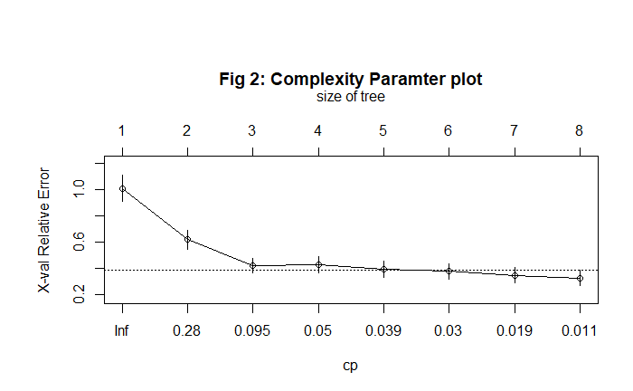

```r
par(mar=c(5,6,9,2))
plotcp(model.rpart)
title(main="Fig 2: Complexity Paramter plot")
```

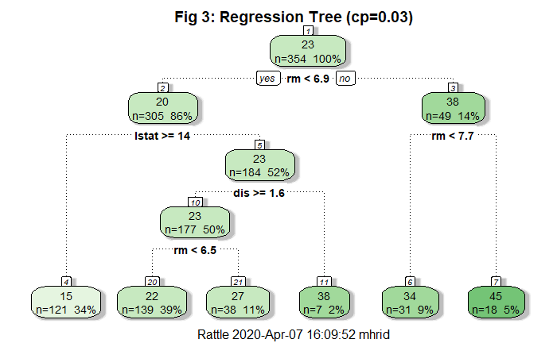

```r
fancyRpartPlot(prune(model.rpart, cp = 0.03),  main = "Fig 3: Regression Tree (cp=0.03)")
```

```r
model.rpart.pred.train <- predict(model.rpart)
model.rpart$ase.train <- mean((model.rpart.pred.train - boston.train$medv)^2)
table$Type[2] <- "Regression Tree"
table$ASE[2] <- model.rpart$ase.train
```

### Bagging

Bagging (Bootstrap and Aggregating) helps to improve prediction accuracy.  
It fits a tree for each bootsrap sample, and then aggregates the predicted values from all trees.  
Plotting the errors against number of trees indicates error flattens after fitting 200 trees.

```r
model.bag <- randomForest(medv ~ ., data=boston.train, mtry=13)
model.bag
```

```
Call:
 randomForest(formula = medv ~ ., data = boston.train, mtry = 13)
               Type of random forest: regression
                     Number of trees: 500
No. of variables tried at each split: 13

          Mean of squared residuals: 12.95996
                    % Var explained: 84.52
```

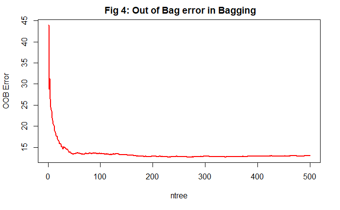

```r
plot(model.bag$mse, type='l', col=2, lwd=2, xlab = "ntree", ylab = "OOB Error", main=" Fig 4: Out of Bag error in Bagging")
```

```r
model.bag.pred.train <- predict(model.bag)
model.bag$ase.train <- mean((model.bag.pred.train - boston.train$medv)^2)
table$Type[3] <- "Bagging"
table$ASE[3] <- model.bag$ase.train
```

### Random Forest

Random Forest is similar to bagging except that we randomly select ‘m’ out of ‘p’ predictors as candidate variables for each split in each tree.  
In the case of regression trees the default $m = p/3$.

We fit trees using Random Forest with default 500 trees.  
We find that **lstat** and **rm** are the most important factors.  
Plotting the Out-of_bag error for these 500 trees shows us that the error seems to flatten after 100 trees.

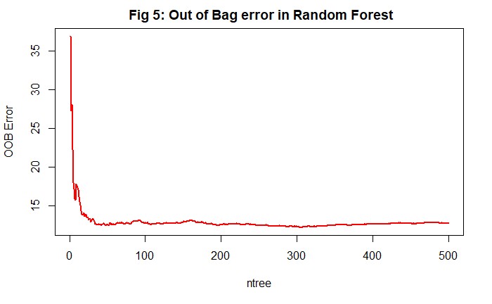

```r
model.rf <- randomForest(medv ~ ., data=boston.train, importance=TRUE, mtry = 5)
plot(model.rf$mse, type='l', col=2, lwd=2, xlab = "ntree", ylab = "OOB Error", main=" Fig 5: Out of Bag error in Random Forest")
```

```r
model.rf.pred.train <- predict(model.rf)
model.rf$ase.train <- mean((model.rf.pred.train - boston.train$medv)^2)
table$Type[4] <- "Random Forest"
table$ASE[4] <- model.rf$ase.train
```

### Boosting Tree

Boosting sequentially builds a number of small trees, and each time, the response is the residual from last tree.  
We choose to fit 5000 trees with a depth of 8 splits, shrinkage parameter = 0.01 and doing a 3-fold CV.  
We find that **lstat** and **rm** are the most important factors.

|  | var | rel.inf |
| --- | --- | --- |
| lstat | lstat | 33.01505545 |
| rm | rm | 32.28286082 |
| dis | dis | 11.28214837 |
| nox | nox | 5.20479333 |
| crim | crim | 4.45477517 |
| age | age | 3.80432058 |
| black | black | 3.17553433 |
| ptratio | ptratio | 2.36075688 |
| tax | tax | 1.90252624 |
| indus | indus | 0.98654590 |

[output cut: 3 more lines]

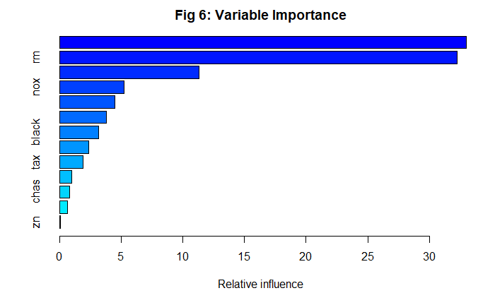

```r
model.boost <- gbm(medv~., data = boston.train, distribution = "gaussian", n.trees = 5000, shrinkage = 0.01, interaction.depth = 8, cv.folds = 3)
summary(model.boost, main="Fig 6: Variable Importance")
```

```r
gbm.perf(model.boost, method = "cv")
```

```
[1] 1393
```

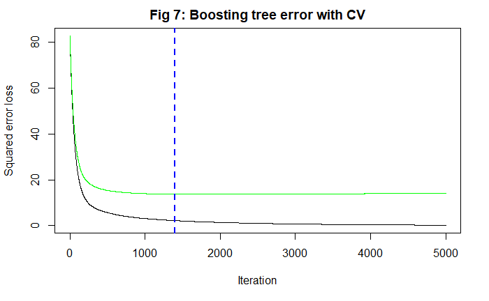

```r
title(main="Fig 7: Boosting tree error with CV")
```

```r
model.boost2 <- gbm(medv~., data = boston.train, distribution = "gaussian", n.trees = 1393, shrinkage = 0.01, interaction.depth = 8, cv.folds = 3)
```

```r
model.boost.pred.train <- predict(model.boost, n.trees = 5000)
model.boost$ase.train <- mean((model.boost.pred.train - boston.train$medv)^2)
model.boost2.pred.train <- predict(model.boost2, n.trees = 1393)
model.boost2$ase.train <- mean((model.boost2.pred.train - boston.train$medv)^2)
table$Type[5] <- "Boosting"
table$ASE[5] <- model.boost2$ase.train
```

### GAM

Generalized Additive Models use a sum of non-paramteric functions over each component of X to capture non-linear relationships.  
**rad** and **chas** are not included in the spline terms as they are quasi-categorical and categorical respectively.  
Each term was checked for significance at 0.05 level vefore removal and if the edf was ~1 it was moved to be a linear term.  
The removal of **age**, **black** and **zn** reduced the GCV score to 11.587 and so that model was selected.

```r
model.gam1 <- gam(medv ~ s(crim)+s(zn)+s(indus)+chas+s(nox)+s(rm)+s(age)+s(dis)+rad+s(tax)+s(ptratio)+s(black)+s(lstat), data=boston.train)
model.gam2 <- gam(medv ~ s(crim)+zn+s(indus)+chas+s(nox)+s(rm)+age+s(dis)+rad+s(tax)+s(ptratio)+black+s(lstat), data=boston.train)
model.gam3 <- gam(medv ~ s(crim)+s(indus)+chas+s(nox)+s(rm)+s(dis)+rad+s(tax)+s(ptratio)+s(lstat), data=boston.train)
model.gam <- model.gam3
summary(model.gam)
```

```
Family: gaussian
Link function: identity

Formula:
medv ~ s(crim) + s(indus) + chas + s(nox) + s(rm) + s(dis) +
    rad + s(tax) + s(ptratio) + s(lstat)

Parametric coefficients:
            Estimate Std. Error t value Pr(>|t|)
(Intercept)  19.1625     1.4757  12.985   <2e-16 ***
chas          1.5598     0.7552   2.065   0.0397 *
rad           0.3488     0.1527   2.284   0.0231 *
---
Signif. codes:  0 ‘***’ 0.001 ‘**’ 0.01 ‘*’ 0.05 ‘.’ 0.1 ‘ ’ 1

Approximate significance of smooth terms:
             edf Ref.df      F  p-value
s(crim)    5.595  6.670  7.399 7.59e-08 ***
s(indus)   4.387  5.284  2.586    0.016 *
s(nox)     8.800  8.973 15.551  < 2e-16 ***
s(rm)      7.165  8.177 19.749  < 2e-16 ***
s(dis)     8.841  8.986 12.283  < 2e-16 ***
s(tax)     7.122  8.049  4.940 8.95e-06 ***
s(ptratio) 2.116  2.667 12.424 7.06e-07 ***
s(lstat)   4.983  6.116 32.104  < 2e-16 ***
---
Signif. codes:  0 ‘***’ 0.001 ‘**’ 0.01 ‘*’ 0.05 ‘.’ 0.1 ‘ ’ 1

R-sq.(adj) =  0.882   Deviance explained = 89.9%
GCV = 11.587  Scale est. = 9.8848    n = 354
```

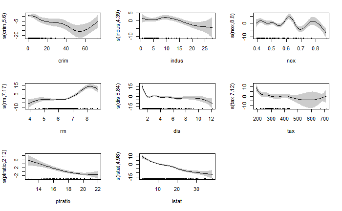

```r
plot(model.gam3, shade=TRUE, seWithMean=TRUE,scale=0,pages=1)
```

```r
model.gam.pred.train <- predict(model.gam)
model.gam$ase.train <- mean((model.gam.pred.train - boston.train$medv)^2)
table$Type[6] <- "GAM"
table$ASE[6] <- model.gam$ase.train
#sum((model.gam.pred.train - boston.train$medv)^2)/model.gam$df.residual
#model.gam$deviance/model.gam$df.residual
```

### Neural Network

The dependent variable is numeric so we set linear.output to be true.  
Multiple models were fit:

1. 1-hidden layer - vary nodes from 1 to 9
2. 2-hidden layers - Vary nodes from 1 to 9 in first layer and vary nodes from 1 to 5 in second layer

The model with 3 nodes in the first layer and 3 nodes in second layer had lower out-sample error and lower variance between in-sample and out-sample errors and so it was picked.

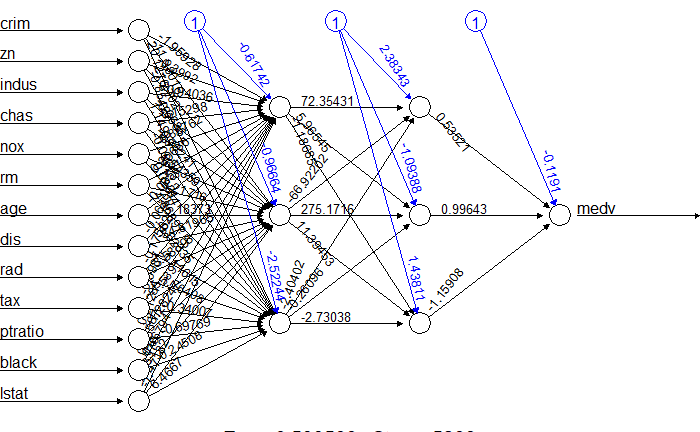

```r
set.seed(13474723)
maxs <- apply(Boston, 2, max)
mins <- apply(Boston, 2, min)
boston.train.scaled <- as.data.frame(scale(boston.train, center = mins, scale = maxs - mins))
boston.test.scaled <- as.data.frame(scale(boston.test, center = mins, scale = maxs - mins))
n <- names(Boston)
f <- as.formula(paste("medv ~", paste(n[!n %in% "medv"], collapse = " + ")))

model.nn <- neuralnet(f,data=boston.train.scaled,hidden=c(3,3),linear.output=T)
plot(model.nn, main="Fig 9: Neural Network (3,3) for Boston Data")
```

```r
model.nn.predict.train <- compute(model.nn, boston.train.scaled)
model.nn.predict.train_ <- model.nn.predict.train$net.result*(max(Boston$medv)-min(Boston$medv))+min(Boston$medv)
boston.train_ <- (boston.train.scaled$medv)*(max(Boston$medv)-min(Boston$medv))+min(Boston$medv)
model.nn.ase.train <- sum((boston.train_ - model.nn.predict.train_)^2)/nrow(boston.train.scaled)
model.nn.predict.test <- compute(model.nn, boston.test.scaled)
model.nn.predict.test_ <- model.nn.predict.test$net.result*(max(Boston$medv)-min(Boston$medv))+min(Boston$medv)
boston.test_ <- (boston.test.scaled$medv)*(max(Boston$medv)-min(Boston$medv))+min(Boston$medv)
model.nn.ase.test <- sum((boston.test_ - model.nn.predict.test_)^2)/nrow(boston.test.scaled)
print(sprintf("In-sample ASE = %s Out-sample ASE = %s",model.nn.ase.train,model.nn.ase.test))
```

```
[1] "In-sample ASE = 6.85969366234796 Out-sample ASE = 11.7419711334397"
```

```r
table$Type[7] <- "Neural Network"
table$ASE[7] <- model.nn.ase.train
```

```r
### Backup code for running iterations
#for (i in c(1,2,3,4,5,6,7,8,9,10)){
#  model.nn <- neuralnet(f,data=boston.train.scaled,hidden=i,linear.output=T)
#  plot(model.nn)
#  model.nn.predict.train <- compute(model.nn, boston.train.scaled)
#  model.nn.predict.train_ <- model.nn.predict.train$net.result*(max(Boston$medv)-min(Boston$medv))+min(Boston$medv)
#
#  boston.train_ <- (boston.train.scaled$medv)*(max(Boston$medv)-min(Boston$medv))+min(Boston$medv)
#  model.nn.ase.train <- sum((boston.train_ - model.nn.predict.train_)^2)/nrow(boston.train.scaled)
#  model.nn.ase.train
#}
#
#for (i in c(1,2,3,4,5,6,7,8,9)){
#  for (j in c(1,2,3,4,5)){
#    set.seed(13474723)
#    model.nn <- neuralnet(f,data=boston.train.scaled,hidden=c(i,j),linear.output=T)
#    #plot(model.nn)
#    model.nn.predict.train <- compute(model.nn, boston.train.scaled)
#    model.nn.predict.train_ <- model.nn.predict.train$net.result*(max(Boston$medv)-min(Boston$medv))+min(Boston$medv)
#
#    print(sprintf("NN(%s,%s)",i,j))
#    boston.train_ <- (boston.train.scaled$medv)*(max(Boston$medv)-min(Boston$medv))+min(Boston$medv)
#    model.nn.ase.train <- sum((boston.train_ - model.nn.predict.train_)^2)/nrow(boston.train.scaled)
#
#    model.nn.predict.test <- compute(model.nn, boston.test.scaled)
#    model.nn.predict.test_ <- model.nn.predict.test$net.result*(max(Boston$medv)-min(Boston$medv))+min(Boston$medv)
#
#    boston.test_ <- (boston.test.scaled$medv)*(max(Boston$medv)-min(Boston$medv))+min(Boston$medv)
#    model.nn.ase.test <- sum((boston.test_ - model.nn.predict.test_)^2)/nrow(boston.test.scaled)
#    print(sprintf("In-sample=%s Out-sample=%s",model.nn.ase.train,model.nn.ase.test))
#  }
#}
```

### Out-of-Sample Validation

Using the best fitted models in each type of regression, we now calculate the Test ASE.

```r
model.linear.pred.test <- predict(model.linear, newdata=boston.test)
model.linear$ase.test <- mean((model.linear.pred.test - boston.test$medv)^2)
table$`Out-Sample`[1] <- model.linear$ase.test

model.rpart.pred.test <- predict(model.rpart, newdata=boston.test)
model.rpart$ase.test <- mean((model.rpart.pred.test - boston.test$medv)^2)
table$`Out-Sample`[2] <- model.rpart$ase.test

model.bag.pred.test <- predict(model.bag, newdata=boston.test)
model.bag$ase.test <- mean((model.bag.pred.test - boston.test$medv)^2)
table$`Out-Sample`[3] <- model.bag$ase.test

model.rf.pred.test <- predict(model.rf, newdata=boston.test)
model.rf$ase.test <- mean((model.rf.pred.test - boston.test$medv)^2)
table$`Out-Sample`[4] <- model.rf$ase.test

model.boost.pred.test <- predict(model.boost, newdata=boston.test, n.trees = 5000)
model.boost$ase.test <- mean((model.boost.pred.test - boston.test$medv)^2)
model.boost2.pred.test <- predict(model.boost2, newdata=boston.test, n.trees = 1393)
model.boost2$ase.test <- mean((model.boost2.pred.test - boston.test$medv)^2)
table$`Out-Sample`[5] <- model.boost2$ase.test

model.gam.pred.test <- predict(model.gam, newdata=boston.test)
model.gam$ase.test <- mean((model.gam.pred.test - boston.test$medv)^2)
table$`Out-Sample`[6] <- model.gam$ase.test

table$`Out-Sample`[7] <- model.nn.ase.test
```

```r
print.data.frame(table)
```

```
               Type       ASE Out-Sample
1 Linear Regression 23.597306  18.688102
2   Regression Tree 16.385094  23.013215
3           Bagging 12.959958  10.727727
4     Random Forest 12.743220   7.157639
5          Boosting  2.106900   6.924797
6               GAM  8.432493  16.161948
7    Neural Network  6.859694  11.741971
```

## Bankruptcy Data

### Executive Summary

The Bankruptcy dataset contains 5436 observations and 13 variables. R1 to R10 are continuous variables contain financial information which will be used as predictor variables, DLRSN is a binary variable where 0 labels not bankrupt, 1 labels bankrupt. Using a 70-30 sample split we fit multiple models on the training data and compare the asymmetric misclassification cost (AMC) using the cut-off probability as 1/36.  
The table below summarizes the methods:

| Sr. | Type | In-sample AMC | Out-Sample AMC |
| --- | --- | --- | --- |
| 1 | Logistic Regression | 0.6651 | 0.6689 |
| 2 | Classification Tree | 0.5007 | 0.6879 |
| 3 | GAM | 0.5719 | 0.6419 |
| 4 | Neural Network | 0.4896 | 0.5984 |

For the logistic regression model AIC criterion was slightly better than BIC and so was picked with out-sample TPR of 96.04%.  
A classification tree with 14 terminal nodes was pruned to have 8 terminal nodes with out-sample TPR of 95.15%.  
The GAM model was built with **R1** and **R4** as linear terms and the rest having splines functions which gave out-sample TPR of 95.60%.  
Finally a Neural Network model was fit with one hidden layer having 7 nodes and decay rate of 0.25 to avoid overfitting. The out-sample TPR was found to be 95.60%.

### Exploratory Data Analysis

Split the data as 70% training and 30% testing.  
For all model training we will stick only to training set.  
In the training set 14.4% of the data has DLRSN=1 which are the cases idicating bankruptcy.  
This implies that the data is imbalanced.

```r
set.seed(13474723)
bankruptcy <- read.csv("C:/Users/mhrid/Desktop/Spring 2020/BANA 7046 - Data Mining/Cases/Case 2/bankruptcy.csv")
bankruptcy$DLRSN <- as.factor(bankruptcy$DLRSN)
index <- sample(nrow(bankruptcy), nrow(bankruptcy)*0.7)
bankruptcy.train <- bankruptcy[index,]
bankruptcy.test <- bankruptcy[-index,]
```

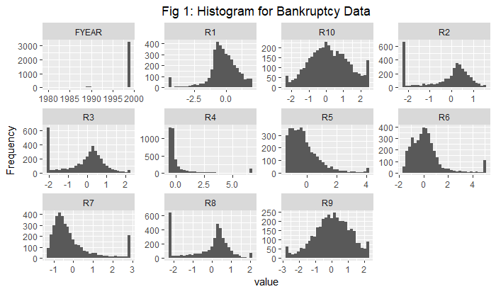

```r
plot_histogram(bankruptcy.train,theme_config = list(plot.title = element_text(hjust = 0.5)), title="Fig 1: Histogram for Bankruptcy Data")
```

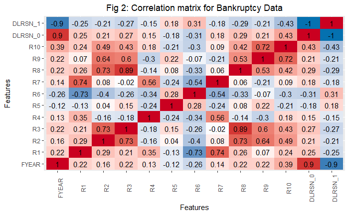

```r
plot_correlation(bankruptcy.train,theme_config = list(plot.title = element_text(hjust = 0.5), legend.position = "none", axis.text.x = element_text(angle=90)), title="Fig 2: Correlation matrix for Bankruptcy Data")
```

```r
table1 <- data.frame(matrix(ncol = 2, nrow = 7))
names(table1) <- c("Type","ASE")
```

```r
cost <- function(r, pi){
  weight1 = 35
  weight0 = 1
  c1 = (r==1)&(pi==0) #FN
  c0 = (r==0)&(pi==1) #FP
  return(mean(weight1*c1+weight0*c0))
}
```

### Logistic Regression

A full model with variables R1 through R10 was fit as a generalized linear model and another null model was fit with only the intercept.  
These two models were used as the upper and lower scopes for finding a best model using AIC and BIC criterions.  
AUC for AIC model (0.882) was slightly better that BIC model (0.88) both being higher than industrial standard of 0.7.  
Since this is imbalanced data we plot the precision-recall curve and see the AUC for AIC model (0.5723) is better than AUC for BIC model (0.5718).  
The asymmetric misclassifaction cost is 0.6652 with:  
Accuracy = 50.46%  
True Positive Rate = 96.54%  
False Positive Rate = 57.31%

```r
summary(glm.AIC)
```

```
Call:
glm(formula = DLRSN ~ R10 + R4 + R8 + R2 + R7 + R3 + R9 + R6 +
    R1, family = binomial(link = "logit"), data = bankruptcy.train)

Deviance Residuals:
    Min       1Q   Median       3Q      Max
-2.3086  -0.4475  -0.2308  -0.0968   3.2790

Coefficients:
            Estimate Std. Error z value Pr(>|z|)
(Intercept) -2.61992    0.08780 -29.840  < 2e-16 ***
R10         -1.53276    0.09789 -15.659  < 2e-16 ***
R4          -0.34574    0.15774  -2.192 0.028388 *
R8          -0.30597    0.09331  -3.279 0.001042 **
R2           0.52925    0.08549   6.191 6.00e-10 ***
R7          -0.43739    0.11457  -3.818 0.000135 ***
R3          -0.49568    0.11062  -4.481 7.43e-06 ***
R9           0.31522    0.09979   3.159 0.001584 **
R6           0.19325    0.05902   3.274 0.001060 **
R1           0.17311    0.07971   2.172 0.029872 *
---
Signif. codes:  0 ‘***’ 0.001 ‘**’ 0.01 ‘*’ 0.05 ‘.’ 0.1 ‘ ’ 1

(Dispersion parameter for binomial family taken to be 1)

    Null deviance: 3140.4  on 3804  degrees of freedom
Residual deviance: 2097.2  on 3795  degrees of freedom
AIC: 2117.2

Number of Fisher Scoring iterations: 7
```

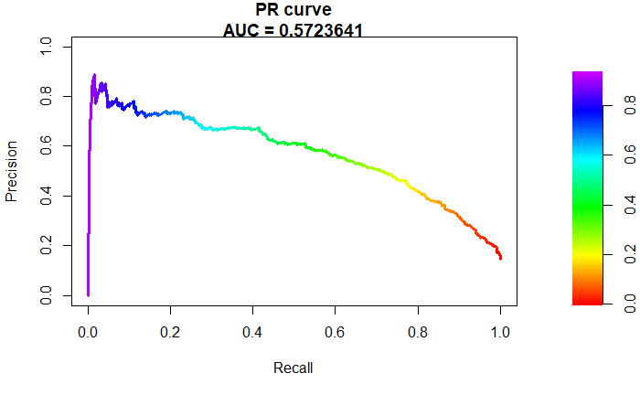

```r
pcut <- 1/(35+1)
glm.BIC.prob.train <- predict(glm.BIC, type="response")
pred <- ROCR::prediction(glm.BIC.prob.train, bankruptcy.train$DLRSN)
perf <- performance(pred, "tpr", "fpr")
#plot(perf, col="green");abline(0,1,lty=2)
#unlist(slot(performance(pred, "auc"), "y.values"))

glm.AIC.prob.train <- predict(glm.AIC, type="response")
pred <- ROCR::prediction(glm.AIC.prob.train, bankruptcy.train$DLRSN)
perf <- performance(pred, "tpr", "fpr")
#plot(perf, add=TRUE, col="red")
#unlist(slot(performance(pred, "auc"), "y.values"))
#title("Fig 3: ROC curves for AIC and BIC models")

score1 <- glm.AIC.prob.train[bankruptcy.train$DLRSN==1]
score0 <- glm.AIC.prob.train[bankruptcy.train$DLRSN==0]
pr <- pr.curve(score1, score0, curve=T)
plot(pr)
```

```r
glm.AIC.pred.train <- (glm.AIC.prob.train>=pcut)*1
table(bankruptcy.train$DLRSN, glm.AIC.pred.train,dnn=c("Observed","Predicted"))
```

```
        Predicted
Observed    0    1
       0 1390 1866
       1   19  530
```

```r
sprintf("AMR = %s",round(cost(bankruptcy.train$DLRSN, glm.AIC.pred.train),4))
```

```
[1] "AMR = 0.6652"
```

### Classification Tree

All the variables from R1 to R10 were used to fit a classification tree as the response is categorical.  
The tree is allowed to grow till cp=0.0075 and then pruned at 0.01 based on plotcp curve.  
The asymmetric misclassifaction cost is 0.5007 with:  
Accuracy = 56.19%  
True Positive Rate = 98.72%  
False Positive Rate = 51.00%

[figure not shown]

```r
bankruptcy.rpart <- rpart(formula = DLRSN ~ R1 + R2 + R3 + R4 + R5 + R6 + R7 + R8 + R9 + R10, method="class", data = bankruptcy.train, cp=0.0075, parms = list(loss=matrix(c(0,35,1,0), nrow = 2)))
bankruptcy.rpart1 <- prune(bankruptcy.rpart, cp = 0.01)
fancyRpartPlot(prune(bankruptcy.rpart, cp = 0.01),  main = "Fig 4: Classification Tree (cp=0.01)")
```

```r
bankruptcy.rpart.pred.train <- predict(bankruptcy.rpart1, type="class")

table(bankruptcy.train$DLRSN,bankruptcy.rpart.pred.train,dnn=c("Observed","Predicted"))
```

```
        Predicted
Observed    0    1
       0 1596 1660
       1    7  542
```

```r
sprintf("AMR = %s",round(cost(bankruptcy.train$DLRSN, bankruptcy.rpart.pred.train),4))
```

```
[1] "AMR = 0.5007"
```

```r
#table$Type[2] <- "Classification Tree"
#table$ASE[2] <- model.rpart$ase.train
```

### GAM

All the variables R1 to R10 are first fitted with splines which show edf=1 for R1 and R4 so we move those to linear terms.  
The models deviance explained is low.  
The asymmetric misclassifaction cost is 0.5718 with:  
Accuracy = 55.32%  
True Positive Rate = 97.44%  
False Positive Rate = 51.78%

```r
bankruptcy.gam1 <- gam(DLRSN ~ s(R1)+s(R2)+s(R3)+s(R4)+s(R5)+s(R6)+s(R7)+s(R8)+s(R9)+s(R10),family=binomial,data=bankruptcy.train)
bankruptcy.gam <- gam(DLRSN ~ R1+s(R2)+s(R3)+R4+s(R5)+s(R6)+s(R7)+s(R8)+s(R9)+s(R10),family=binomial,data=bankruptcy.train)
summary(bankruptcy.gam)
```

```
Family: binomial
Link function: logit

Formula:
DLRSN ~ R1 + s(R2) + s(R3) + R4 + s(R5) + s(R6) + s(R7) + s(R8) +
    s(R9) + s(R10)

Parametric coefficients:
            Estimate Std. Error z value Pr(>|z|)
(Intercept) -2.95980    0.12348 -23.969   <2e-16 ***
R1           0.14578    0.09706   1.502   0.1331
R4          -0.41511    0.17116  -2.425   0.0153 *
---
Signif. codes:  0 ‘***’ 0.001 ‘**’ 0.01 ‘*’ 0.05 ‘.’ 0.1 ‘ ’ 1

Approximate significance of smooth terms:
         edf Ref.df Chi.sq  p-value
s(R2)  4.060  5.007 67.777 3.03e-13 ***
s(R3)  1.866  2.371 12.281  0.00398 **
s(R5)  3.001  3.723  6.864  0.11932
s(R6)  5.276  6.374 58.815 1.91e-10 ***
s(R7)  1.774  2.231  3.155  0.21249
s(R8)  5.418  6.493 37.253 3.29e-06 ***
s(R9)  2.505  3.189  8.501  0.04278 *
s(R10) 2.037  2.604 97.284  < 2e-16 ***
---
Signif. codes:  0 ‘***’ 0.001 ‘**’ 0.01 ‘*’ 0.05 ‘.’ 0.1 ‘ ’ 1

R-sq.(adj) =   0.37   Deviance explained = 38.8%
UBRE = -0.47997  Scale est. = 1         n = 3805
```

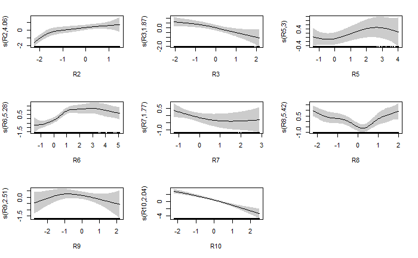

```r
plot(bankruptcy.gam, shade=TRUE, seWithMean=TRUE,scale=0,pages=1)
```

```r
pcut <- 1/(35+1)
bankruptcy.gam.prob.train <- predict(bankruptcy.gam, type="response")
bankruptcy.gam.pred.train <- (bankruptcy.gam.prob.train>=pcut)*1
table(bankruptcy.train$DLRSN,bankruptcy.gam.pred.train,dnn=c("Observed","Predicted"))
```

```
        Predicted
Observed    0    1
       0 1570 1686
       1   14  535
```

```r
sprintf("AMR = %s",round(cost(bankruptcy.train$DLRSN, bankruptcy.gam.pred.train),4))
```

```
[1] "AMR = 0.5719"
```

### Neural Network

The dependent variable is categorical.  
Using the nnet function we try different sizes and see that with get good in-sample and out-sample asymetric costs with size=7.  
The asymmetric misclassifaction cost is 0.4896 with:  
Accuracy = 61.76%  
True Positive Rate = 97.81%  
False Positive Rate = 44.32%

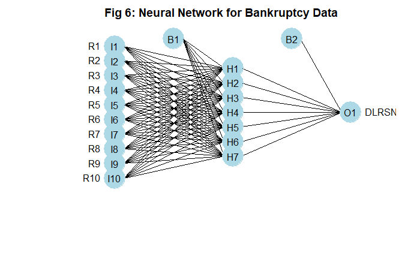

```r
set.seed(13474723)
bankruptcy.nnet <- nnet(DLRSN ~ R1 + R2 + R3 + R4 + R5 + R6 + R7 + R8 + R9 + R10, data=bankruptcy.train, size=7, maxit=1000, decay=0.25)
plot(bankruptcy.nnet, nid=F, main="Fig 6: Neural Network for Bankruptcy Data")
```

```r
bankruptcy.nnet.prob.train <- predict(bankruptcy.nnet, bankruptcy.train)
bankruptcy.nnet.pred.train <- as.numeric(bankruptcy.nnet.prob.train >= pcut)*1
table(bankruptcy.train$DLRSN, bankruptcy.nnet.pred.train, dnn=c("Observed","Predicted"))
```

```
        Predicted
Observed    0    1
       0 1813 1443
       1   12  537
```

```r
sprintf("AMR = %s",round(cost(bankruptcy.train$DLRSN, bankruptcy.nnet.pred.train),4))
```

```
[1] "AMR = 0.4896"
```

### Out-of-Sample Validation

```r
pcut <- 1/(1+35)
glm.AIC.prob.test <- predict(glm.AIC, newdata=bankruptcy.test, type="response")
glm.AIC.pred.test <- (glm.AIC.prob.test>=pcut)*1
table(bankruptcy.test$DLRSN, glm.AIC.pred.test, dnn=c("Observed","Predicted"))
```

```
        Predicted
Observed   0   1
       0 628 776
       1   9 218
```

```r
sprintf("Logistic Regression AMR = %s",round(cost(bankruptcy.test$DLRSN, glm.AIC.pred.test),4))
```

```
[1] "Logistic Regression AMR = 0.6689"
```

```r
bankruptcy.rpart.pred.test <- predict(bankruptcy.rpart1, newdata=bankruptcy.test, type="class")
table(bankruptcy.test$DLRSN, bankruptcy.rpart.pred.test, dnn=c("Observed","Predicted"))
```

```
        Predicted
Observed   0   1
       0 667 737
       1  11 216
```

```r
sprintf("Classification Tree AMR = %s",round(cost(bankruptcy.test$DLRSN, bankruptcy.rpart.pred.test),4))
```

```
[1] "Classification Tree AMR = 0.6879"
```

```r
bankruptcy.gam.prob.test <- predict(bankruptcy.gam, newdata=bankruptcy.test, type="response")
bankruptcy.gam.pred.test <- (bankruptcy.gam.prob.test >= pcut)*1
table(bankruptcy.test$DLRSN, bankruptcy.gam.pred.test, dnn=c("Observed","Predicted"))
```

```
        Predicted
Observed   0   1
       0 707 697
       1  10 217
```

```r
sprintf("GAM AMR = %s",round(cost(bankruptcy.test$DLRSN, bankruptcy.gam.pred.test),4))
```

```
[1] "GAM AMR = 0.6419"
```

```r
bankruptcy.nnet.prob.test <- predict(bankruptcy.nnet, bankruptcy.test)
bankruptcy.nnet.pred.test <- as.numeric(bankruptcy.nnet.prob.test >= pcut)*1
table(bankruptcy.test$DLRSN, bankruptcy.nnet.pred.test, dnn=c("Observed","Predicted"))
```

```
        Predicted
Observed   0   1
       0 778 626
       1  10 217
```

```r
sprintf("AMR = %s",round(cost(bankruptcy.test$DLRSN, bankruptcy.nnet.pred.test),4))
```

```
[1] "AMR = 0.5984"
```